# GDP and Life Expectancy Report (2025)

## Introduction

This report analyzes two key development indicators for the year 2025:

1. **GDP per Capita** - a measure of economic prosperity
2. **Life Expectancy** - a measure of population health

## GDP per Capita (2025)

In 2025, GDP per capita across 193 countries ranged from **$716** (South Sudan) to **$475,911** (Monaco), with a median of **$16,540**.

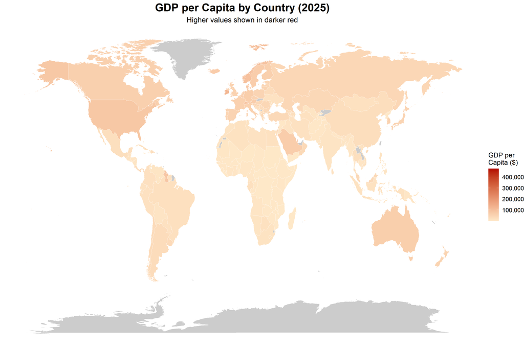

World Map of GDP per Capita (2025)

## Life Expectancy (2025)

In 2025, life expectancy across 193 countries ranged from **52.8 years** (Lesotho) to **85.6 years** (Singapore), with a median of **74.8 years**.

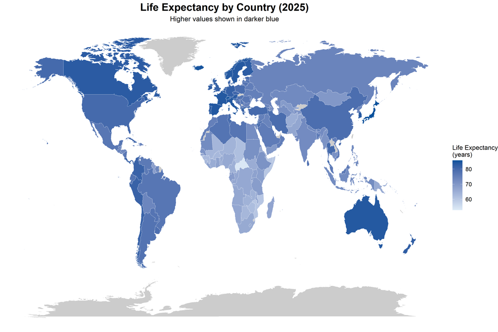

World Map of Life Expectancy (2025)

## Relationship Between GDP and Life Expectancy

The following scatterplot shows the relationship between GDP per capita and life expectancy for 193 countries in 2025.

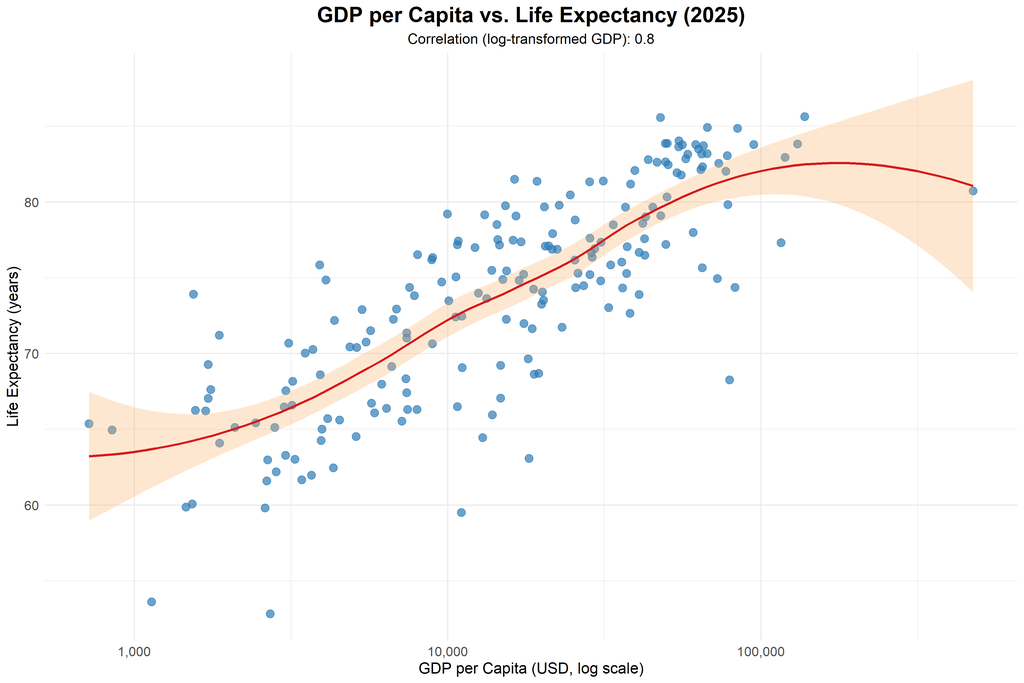

Relationship Between GDP per Capita and Life Expectancy (2025)

### Interpretation

The scatterplot reveals a **strong positive relationship** between GDP per capita and life expectancy (correlation with log-transformed GDP: **r = 0.8**). Key observations:

1. **Diminishing Returns**: The relationship follows a logarithmic pattern. Countries with very low GDP see large gains in life expectancy with modest economic growth, but the gains level off at higher income levels.
2. **Income Threshold**: Below approximately $10,000 GDP per capita, there is substantial variation in life expectancy. Above this threshold, most countries achieve life expectancies of 75+ years.
3. **Economic Development and Health**: Wealthier countries generally provide better healthcare, nutrition, sanitation, and education—all factors that contribute to longer lives.
4. **Outliers**: Some countries outperform their expected life expectancy given their income level (likely due to strong public health systems), while others underperform (possibly due to conflict, disease burden, or inequality).

This pattern is consistent with the well-established Preston Curve, which demonstrates that the relationship between income and health is strongest at lower income levels.

## Summary

| Indicator | Minimum | Median | Maximum |
| --- | --- | --- | --- |
| GDP per Capita | $716 (South Sudan) | $16,540 | $475,911 (Monaco) |
| Life Expectancy | 52.8 years (Lesotho) | 74.8 years | 85.6 years (Singapore) |

## Own reflection

It was easy to follow the instructions, but will be more challenging to really understand the code.